# Project2 Phase 2

Ziad Al Bkhetan, Neven Piculjan, Naveen Mupparapu

January 7, 2016

# Internet of Things - Introduction

In the second phase we should cluster the records in the dataset, then try to charactrize these clusters and find some intersting patterns for these visits.

We Assumed That the visit is the duration between the minimum date and maximum date for the same visitor in the same station, in the same day.

we used a dataset contains 500000 records, and we analysed it, just to make the performance faster.

# Data Loading And Cleaning

In this step we will prepare the data set to start analysis phase, we assumed that the maybe the dataset is not sorted, so we sort it based on the visitor and date.

We removed the records when the visitor is -1, because they are incorrect data.

```r
library(tidyr)
library(dplyr)
library(ggplot2)
library(cluster)
library(caret)
load('D:/MSc Computer science and informatics/3rd semester/Data Mining - Advances/Lab Projects/Project 2/SmallLogs_n.rda')

# Cleaning
orderedData = arrange(orderedData, visitor, station, date)
orderedData = filter(orderedData, visitor != -1)
```

# Prepare The Final DataSet

in this step we will fetch all needed data for analysis and visualization, and the most important for us are: Visitor ID, Station, Consumed Time, Day, and Hour.

we grouped all the data based on the visitor and the station and the visit day, because each visit should be in one day, and the card is valid for one day.

After that we calculated the visit duration as the difference between the minimum and maximum time for each visitor in each station in the same day, this difference is calculated in minutes.

For Clustering, We decided to cluster these visits based on two different datasets

The First one is a normalized dataset, and we will use these variables to calculate the distances

- the consumed time in each visit
- Start Time

We Normalized the Data, to reduce the effect of variables values range when calculate the distnces.

The second Dataset, using the interactions in each visit, so we put one if the page was visited, and zero if not, then we calcualte the ditances based on the similar visited pages.

```r
orderedDataFinal = orderedData %>%
  group_by(Visitor=visitor, dat=format(date, format="%Y:%m:%d") , Station=station) %>%
  summarise(
    start_time = min(date),
    send_time = max(date),
    Cons_time = difftime(max(date), min(date),units='mins'),
    WDay = as.POSIXlt(min(date))$wday,
    THour = as.POSIXlt(min(date))$hour

  )
finalData <- orderedDataFinal
finalData$Cons_time <- as.numeric(finalData$Cons_time)
finalData$Station <- factor(finalData$Station)
finalData <- filter(finalData, Cons_time > 1)

finalData <- filter(finalData, Cons_time < 5)
indxData <- createDataPartition(y = finalData$Station, p = 0.8)
finalData<- finalData[indxData$Resample1,]
indxData <- createDataPartition(y = finalData$THour, p = 0.8)
finalData<- finalData[indxData$Resample1,]


# Create Normalized Variables based on the original Variables

finalData$start_date_n = as.numeric(finalData$start_time)
finalData$Cons_time_n = as.numeric(finalData$Cons_time)
finalData$WDay_n = as.numeric(finalData$WDay)
finalData$THour_n = as.numeric(finalData$THour)

# Data normalization
normalize <- function(x) {
  scale(x)
}


normalized_data <- as.data.frame(lapply(finalData[, 9:12], normalize))

finalData$start_date_n <- normalized_data$start_date_n
finalData$Cons_time_n <- normalized_data$Cons_time_n
finalData$WDay_n <- normalized_data$WDay_n
finalData$THour_n <- normalized_data$THour_n


# Using the interactions for clustering

finalData_2 =  orderedData
finalData_2$scene <- substring(finalData_2$scene, regexpr("sceneId=", finalData_2$scene) + 8, regexpr(">", finalData_2$scene) - 1)
finalData_2$dat=format(finalData_2$date, format="%Y:%m:%d")

finalData_for_interactions = finalData_2 %>%
  group_by(Visitor=visitor, dat, Station=station, scene) %>%
  summarise(count = 1) %>%
  spread(scene, count, fill=0)

rm(normalized_data, finalData_2, orderedData)
finalData_for_interactions <- finalData_for_interactions[1:2000,]
```

# Clustering Using the normalized Dataset

in this part we will apply K-means and Pam methods on th e normalized dataset, and we will choose the model with high average silhouette value as the final model.

## K-Means

Starting with K-means clustering, we will try to cluster the observations into different numbers of clusters, and compare the averave silhouette values

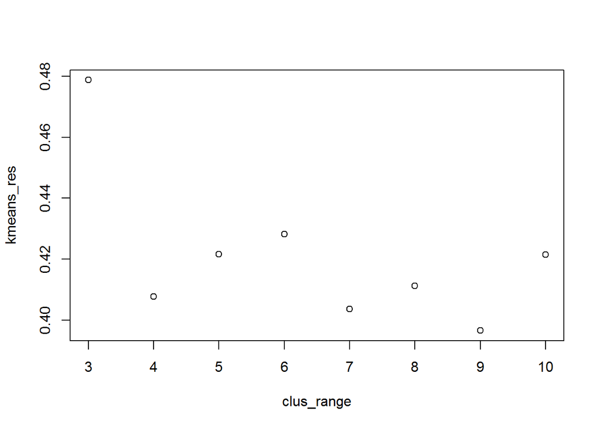

```r
clus_range <- seq(3, 10, 1)
k_meanslst <- list()
for (i in clus_range)
{
  k_meanslst[[i - 2]] <- kmeans(finalData[,c("start_date_n","Cons_time_n")], i)
}
k_meanslst <- k_meanslst [!sapply(k_meanslst, is.null)]

des <- daisy(as.matrix(finalData[,c("start_date_n","Cons_time_n")]))
kmeans_res <- sapply(k_meanslst, function(x) mean(silhouette(x$cl, des)[, 3]))
plot(clus_range, kmeans_res)
```

## Choosen K-Means Model

Here we selected the model with the highest average silhouette value, then we visualized the data based on the start date and the consumed time

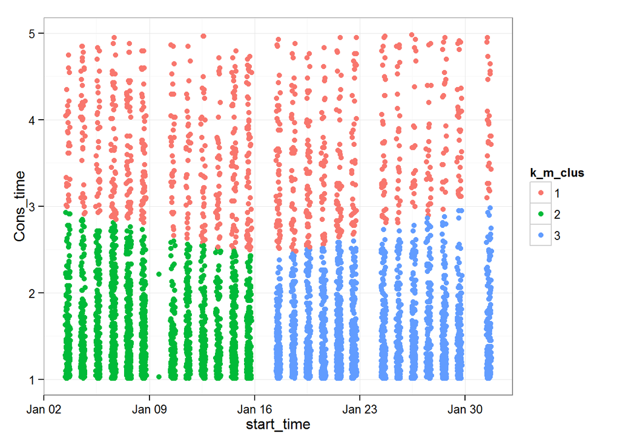

```r
k_means_mod <- k_meanslst [[match(max(kmeans_res),kmeans_res)]]
finalData$k_m_clus = factor(k_means_mod$cluster)

ggplot(finalData, aes(start_time, Cons_time)) +
  geom_point(aes(color=k_m_clus), size=2)+
  theme_bw()
```

We can see from this plot that the data is clustered into three different clusters which are well separated.

One of them mainly depends on the consumed time, and we think even that the data was normalized but there is a slight effect related to the values range, this cluster contains the visits which have consumed time bigger than three minutes. while both of the second and the third clusters contain the records which have consumed time less than three (approximatly), but the visits in one of them started before jan 16, and the other after 16 Jan.

## PAM

Here we will use Pam method to cluster the data, and also we will use different clusters numbers and compare the average silhouette values

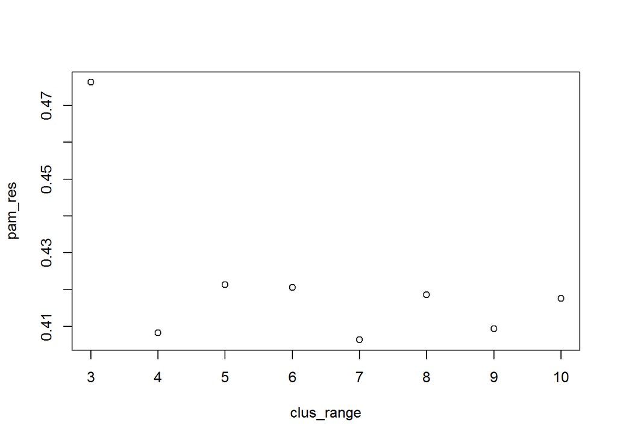

```r
pam_lst <- list()
for (i in clus_range)
{
  pam_lst[[i - 2]] <- pam(finalData[,c("start_date_n","Cons_time_n")], i)
}
pam_lst <- pam_lst [!sapply(pam_lst, is.null)]
pam_res <- sapply(pam_lst, function(x) mean(silhouette(x)[, 3]))
plot(clus_range, pam_res)
```

## Choosen Pam Model

Also we will chose the model with the highest silhouette value.

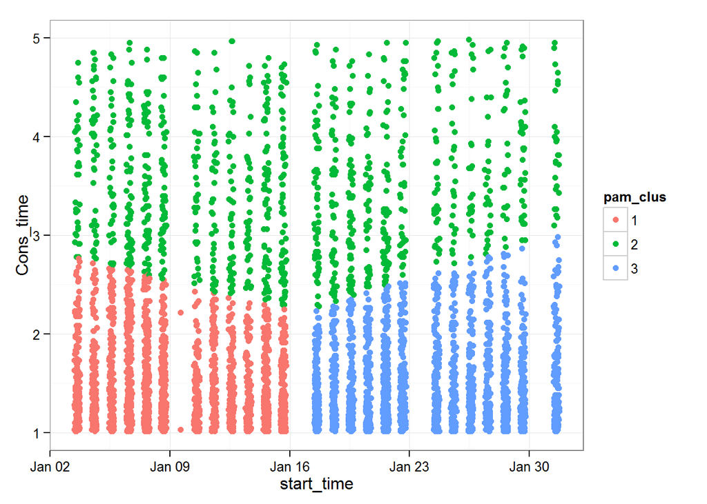

```r
pam_mod <- pam_lst [[match(max(pam_res),pam_res)]]
finalData$pam_clus = factor(pam_mod$clustering)

ggplot(finalData, aes(start_time, Cons_time)) +
  geom_point(aes(color=pam_clus), size=2)+
  theme_bw()
```

We can see from the plot that it is simmilar to the k-means clusters, but this model is stable, and we will get the same clusters when we repeat it.

# Clustering Using Interactions Dataset

Here we have different approach to use for clustering, We will try to find the similar visits based on the visited pages in each visit. then we will cluster these visits. we beleive that in real life this approach is practical especially for marketing purposes when you can recommend the rest of the visted pages for similar visitors.

we will apply K-means only after finding the best model

## K-means Clustering

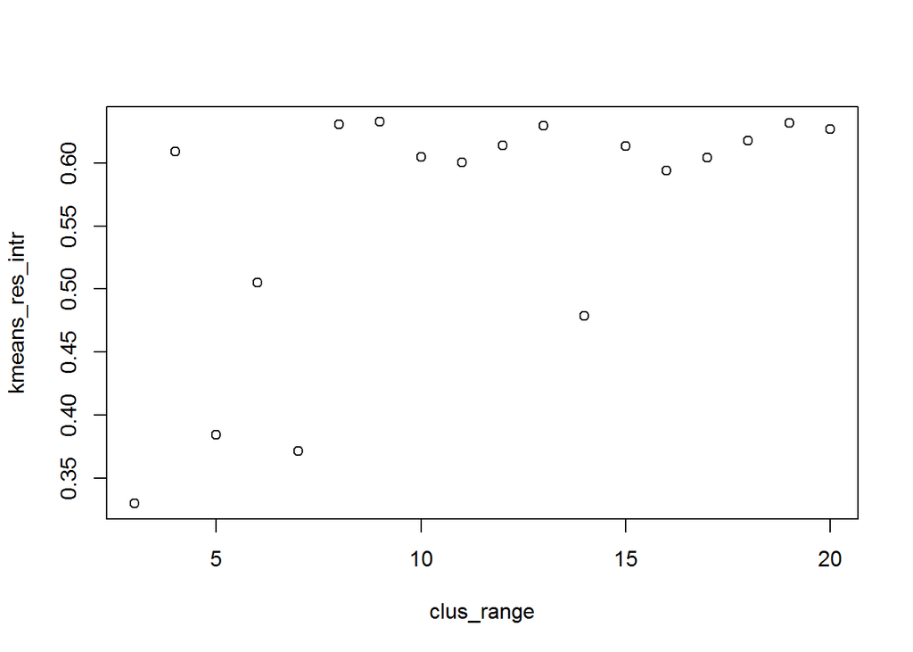

```r
clus_range <- seq(3, 20, 1)
col_names_intr <- colnames(finalData_for_interactions)
col_names_intr <- col_names_intr[4:33]
k_meanslst_intr <- list()
for (i in clus_range)
{
  k_meanslst_intr[[i - 2]] <- kmeans(finalData_for_interactions[,col_names_intr], i)
}
k_meanslst_intr <- k_meanslst_intr [!sapply(k_meanslst_intr, is.null)]

des <- daisy(as.matrix(finalData_for_interactions[,col_names_intr]))
kmeans_res_intr <- sapply(k_meanslst_intr, function(x) mean(silhouette(x$cl, des)[, 3]))
plot(clus_range, kmeans_res_intr)
```

## Choosen Model based on Interactions Dataset and K-means method

```r
print (paste("Clusters: ", match(max(kmeans_res_intr),kmeans_res_intr) + 2 , "silhouette : ", max(kmeans_res_intr)))
```

```
## [1] "Clusters:  9 silhouette :  0.632547065820085"
```

```r
k_means_mod_Int <- k_meanslst_intr [[match(max(kmeans_res_intr),kmeans_res_intr)]]
finalData_for_interactions$k_m_i_clus = factor(k_means_mod_Int$cluster)

for (cls in  unique(finalData_for_interactions$k_m_i_clus))
{
  temp <- filter(finalData_for_interactions, k_m_i_clus == cls)
  str <- paste("Cluster : ", cls, " Pages : ")
  for (col in col_names_intr)
  {
    su <- sum(temp[, col])
    if (su > 5 )
    {
      str <- paste(str, " ", col)
    }

  }
  print (str)
}
```

```
## [1] "Cluster :  1  Pages :    CustomRemovalWarningScene   Screen   Splash"
## [1] "Cluster :  9  Pages :    LevelOneMain   LevelThreeMain   LevelTwoMain   MainMenu   removalWarningScene   Results   Splash"
## [1] "Cluster :  8  Pages :    ComicStripNext   ComicStripPre   Info   Info1   Menu   removalWarningScene   Screen1   Splash   TakeAPill"
## [1] "Cluster :  6  Pages :    Attention1   Attention2   Attention3   AttentionResult   BonusGame   Info   Memory1   Memory2   Memory3   MemoryResult   Menu   removalWarningScene   Splash   VisualSpatialSense1   VisualSpatialSense2   VisualSpatialSense3   VisualSpatialSenseResult"
## [1] "Cluster :  4  Pages :    Attention1   Memory1   Memory2   Memory3   MemoryResult   Menu   Splash"
## [1] "Cluster :  7  Pages :    Attention1   Attention2   AttentionResult   Memory1   Memory2   Memory3   Menu   Splash   VisualSpatialSense1   VisualSpatialSense2   VisualSpatialSense3   VisualSpatialSenseResult"
## [1] "Cluster :  2  Pages :    Attention1   Attention2   Attention3   AttentionResult   Memory1   Memory2   Memory3   MemoryResult   Menu   Splash   VisualSpatialSense1"
## [1] "Cluster :  3  Pages :    Attention1   Attention2   Attention3   AttentionResult   Info   Menu   Screen1   Splash"
## [1] "Cluster :  5  Pages :    Attention1   Attention2   AttentionResult   Memory1   Memory2   Memory3   MemoryResult   Menu   removalWarningScene   Splash   VisualSpatialSense1   VisualSpatialSense2   VisualSpatialSense3   VisualSpatialSenseResult"
```

# Statistics

here we will show some statistical information extracted from the these clusters

## K-means method using the normalized Dataset

### Visits in each Cluster

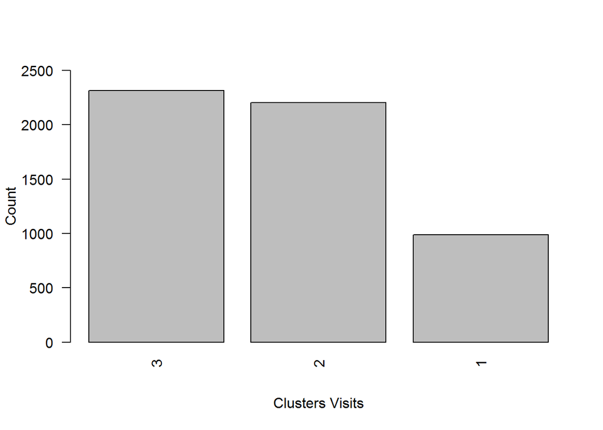

```r
WeeksDays <- c("Sun", "Mon", "Tue", "Wed", "Thu", "Fri", "Sat")

vis_data = finalData %>%
  group_by(k_m_clus) %>%
  summarise(
    s_count = n()
  )
x = vis_data$s_count
names(x) <- vis_data$k_m_clus
x <- sort(x, decreasing = TRUE)
barplot(x, las=2, xlab = "Clusters Visits", ylab = 'Count', ylim = c(0,2500))
```

### Visitors distribution in the Clusters

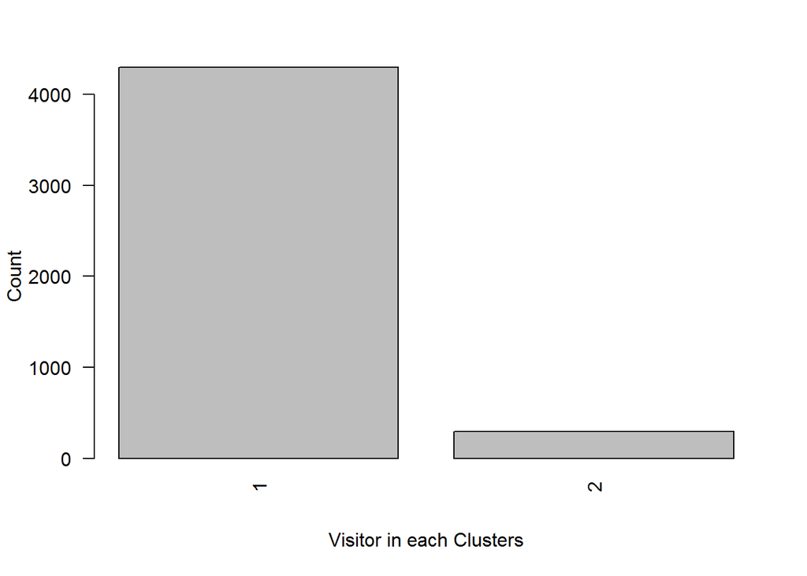

```r
vis_data = finalData %>%
  group_by(Visitor) %>%
  summarise(
    s_count = length(unique(k_m_clus))
  )

vis_data = vis_data %>%
  group_by(s_count) %>%
  summarise(
    s_count_n = n()
  )

x = vis_data$s_count_n
names(x) <- vis_data$s_count
x <- sort(x, decreasing = TRUE)
barplot(x, las=2, xlab = "Visitor in each Clusters", ylab = 'Count', ylim = c(0,4000))
```

### Stations in each Cluster

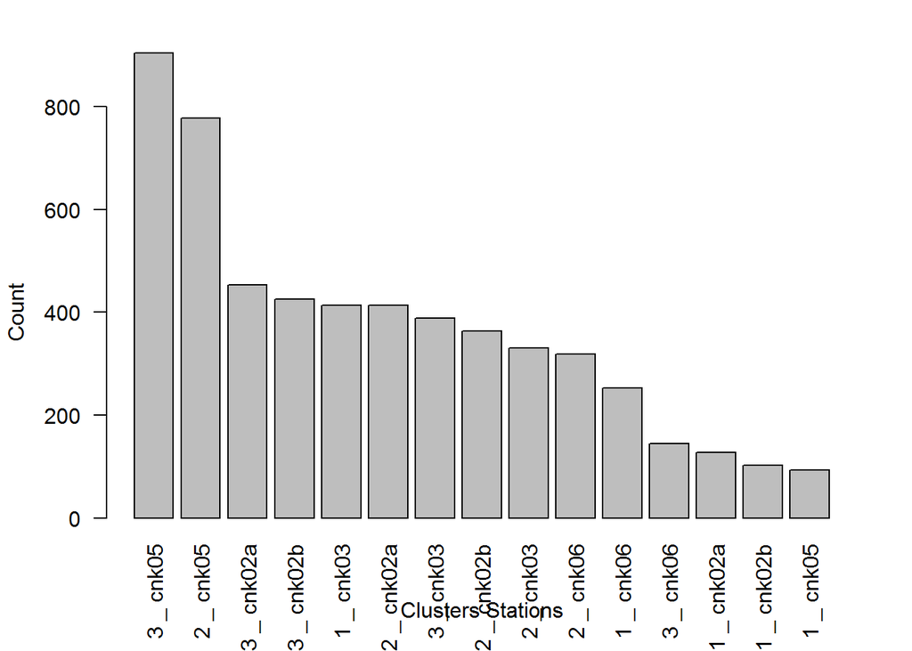

```r
vis_data = finalData %>%
  group_by(k_m_clus, Station) %>%
  summarise(
    s_count = n()
  )
x = vis_data$s_count
names(x) <- paste(vis_data$k_m_clus, "_", vis_data$Station)
x <- sort(x, decreasing = TRUE)
barplot(x, las=2, xlab = "Clusters Stations", ylab = 'Count', ylim = c(0,800))
```

We can see in this plot that the maximum visits count are in the second and third clusters in the station cnk05, while the minimum are in the first cluster in the stations cnk05, cnk02b, and cnk02a.

and we can find that all stations exist in all clusters.

### Start Hours in each Cluster

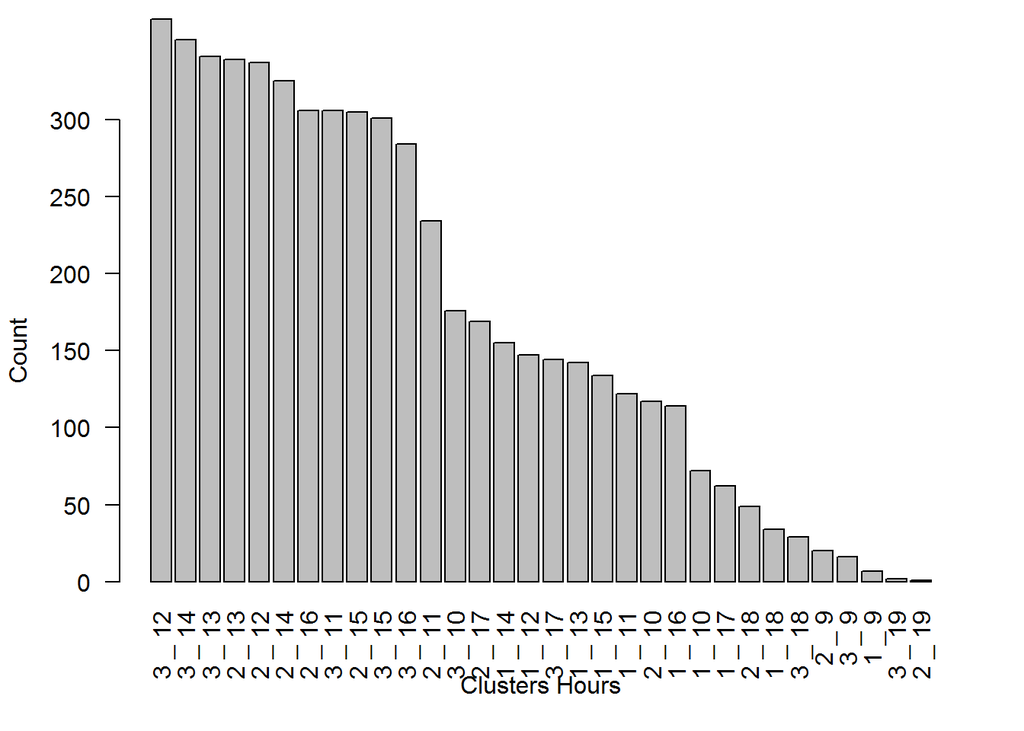

```r
vis_data = finalData %>%
  group_by(k_m_clus, THour) %>%
  summarise(
    s_count = n()
  )

x = vis_data$s_count
names(x) <- paste(vis_data$k_m_clus, "_", vis_data$THour)
x <- sort(x, decreasing = TRUE)
barplot(x, las=2, xlab = "Clusters Hours", ylab = 'Count', ylim = c(0,300))
```

The main idea we can find in this plot is: the maximum visits count in each clusters are in the hours 12, 13, 14, which is the half of the day, whiel the minimum also for all of them at the begining and the end of the day.

### Days in each Cluster

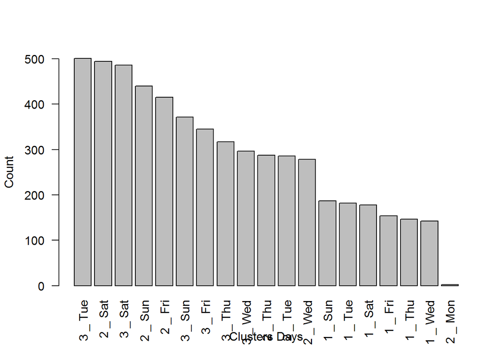

```r
vis_data = finalData %>%
  group_by(k_m_clus, WDay) %>%
  summarise(
    s_count = n()
  )

x = vis_data$s_count
names(x) <- paste(vis_data$k_m_clus, "_", WeeksDays[vis_data$WDay + 1])
x <- sort(x, decreasing = TRUE)
barplot(x, las=2, xlab = "Clusters Days", ylab = 'Count', ylim = c(0,500))
```

## K-means method using the Interactions Dataset

### Stations in each Cluster

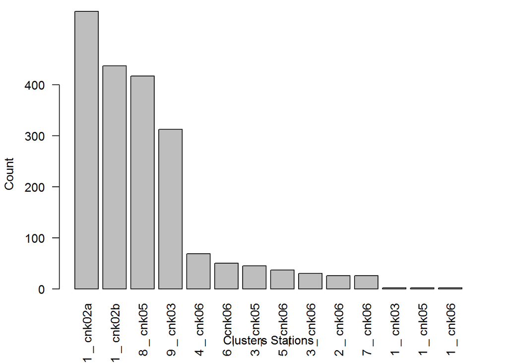

```r
vis_data = finalData_for_interactions %>%
  group_by(k_m_i_clus, Station) %>%
  summarise(
    s_count = n()
  )
x = vis_data$s_count
names(x) <- paste(vis_data$k_m_i_clus, "_", vis_data$Station)
x <- sort(x, decreasing = TRUE)
barplot(x, las=2, xlab = "Clusters Stations", ylab = 'Count', ylim = c(0,450))
```

We can see that most of the stations are in the first cluster, while other clusters contain few different stations